# DMHR Assignment 2018

### Question 4: Identify for all GP-practices the associated nine English regions. Identify for each region the associated 75 mortality rate for cardiovascular diseases for the year 2015.

```python
#Create new postcode column in practices_df with no spaces.
practices_df['Postcode2'] = practices_df['Postcode'].str.replace(" ", "")

#Merge practices_df and ONS_df.
merged5 = pd.merge(practices_df, ONS_df[['Postcode 1', 'Region Name']], left_on='Postcode2', right_on='Postcode 1')

#Tabulate the GP practices and their ssociated regions.
gppractice_region = pd.DataFrame({'Practice' : pd.Series(merged5['Practice']),
                                  'Practice Name' : pd.Series(merged5['Practice name']),
                                  'Region' : pd.Series(merged5['Region Name'])})

gppractice_region = gppractice_region[['Practice', 'Practice Name', 'Region']]
gppractice_region.head()
```

|  | Practice | Practice Name | Region |
| --- | --- | --- | --- |
| 0 | A81001 | THE DENSHAM SURGERY | North East |
| 1 | A81025 | THE DOVECOT SURGERY | North East |
| 2 | A81632 | LAWSON STREET PRACTICE | North East |
| 3 | Y04079 | VIRGINCARE STOCKTON LLP(STOCKTON) | North East |
| 4 | A81002 | QUEENS PARK MEDICAL CENTRE | North East |

```python
#Select data from mortrate_df.
mortrate_2015 = mortrate_df.loc[(mortrate_df['Breakdown'] == 'Region') & (mortrate_df['Year'] == 2015) & (mortrate_df['Gender'] == 'Person')]

#Change the data types of 'Numerator and 'Denominator' from 'object' to 'int64'.
mortrate_2015['Numerator'] = mortrate_2015['Numerator'].str.replace(',','').astype(int)
mortrate_2015['Denominator'] = mortrate_2015['Denominator'].str.replace(',','').astype(int)

#Group mortrate_2015 by 'Level description'.
mortrate_2015_2 = mortrate_2015.groupby('Level description', as_index=False).sum()
```

```python
#Add a new column 'Mortality Rate' in mortrate_2015_2.
mortrate_2015_2['Mortality Rate Per 100000'] = ((mortrate_2015_2['Numerator'] / mortrate_2015_2['Denominator'])*100000).round()

#Tabulate the mortality rates by region.
mortrate_2015_3 = pd.DataFrame({'Region' : pd.Categorical(mortrate_2015_2['Level description']),
                                'Mortality Rate Per 100000' : pd.Series(mortrate_2015_2['Mortality Rate Per 100000'])})

mortrate_2015_3 = mortrate_2015_3[['Region', 'Mortality Rate Per 100000']]
mortrate_2015_3
```

|  | Region | Mortality Rate Per 100000 |
| --- | --- | --- |
| 0 | East Midlands | 74.0 |
| 1 | East of England | 63.0 |
| 2 | London | 49.0 |
| 3 | North East | 83.0 |
| 4 | North West | 82.0 |
| 5 | South East | 57.0 |
| 6 | South West | 67.0 |
| 7 | West Midlands | 72.0 |
| 8 | Yorkshire and The Humber | 76.0 |

### Question 5: Visualize (using matplotlib) for each region spending for statins [x-axis] and the mortality rate [y-axis]. Assess whether relative speaking for statin prescriptions in each regions correlates with the mortality rate from cardiovascular diseases.

```python
#Merge merged5 and statins_data4.
merged6 = pd.merge(merged5, statins_data4)

#Group merged5 by 'Region Name'.
statins_data5 = merged6.groupby('Region Name', as_index=False).sum()

#Merge statins_data5 and mortrate_2015_3.
merged7 = pd.merge(statins_data5[['Region Name', 'Act Cost']], mortrate_2015_3, left_on='Region Name', right_on='Region')
```

```
Text(0,0.5,'Mortality Rate Per 100000')
```

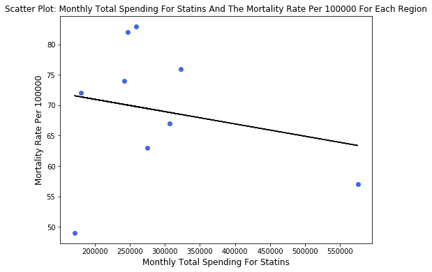

```python
#Data.
x = merged7['Act Cost']
y = merged7['Mortality Rate Per 100000']

#Create scatter plot.
fig = plt.figure(figsize=(8, 6))
ax6 = fig.add_subplot(111)

rects1 = ax6.scatter(x, y, color='royalblue')
fit = np.polyfit(x, y, deg=1)
ax6.plot(x, fit[0] * x + fit[1], color='black')
ax6.set_title('Scatter Plot: Monthly Total Spending For Statins And The Mortality Rate Per 100000 For Each Region')
ax6.set_xlabel("Monthly Total Spending For Statins",fontsize=12)
ax6.set_ylabel("Mortality Rate Per 100000",fontsize=12)
```